# Hand Written Digit Recognition using Neural Network (Keras)

## Sthanu Ramakrishnan

```python
import keras
from keras.layers import Dense
from keras.models import Sequential
from keras.optimizers import SGD, Adam, Adagrad, Adadelta, RMSprop
from keras.callbacks import EarlyStopping

from sklearn.model_selection import train_test_split
SEED=1
from sklearn.metrics import confusion_matrix
from sklearn.metrics import accuracy_score
from sklearn.metrics import classification_report
from matplotlib.colors import ListedColormap # For manually changing colors in Confusion Matrix Heat Map


import numpy as np
import pandas as pd
import matplotlib.pyplot as plt
import seaborn as sns; sns.set(); sns.set(font_scale=1.3)


from hyperopt import Trials, STATUS_OK, tpe
from keras.utils import np_utils
from hyperas import optim
from hyperas.distributions import choice, uniform
# https://github.com/maxpumperla/hyperas
```

### Semeion Handwritten Digit Data Set

1593 handwritten digits from around 80 persons were scanned, stretched in a rectangular box 16x16 in a gray scale of 256 values.

Source : https://archive.ics.uci.edu/ml/datasets/Semeion+Handwritten+Digit

# Reading the data and Data Transformation

```python
# https://stackoverflow.com/questions/19056125/reading-a-file-into-a-multidimensional-array-with-python
with open("semeion.data") as textFile:
    data = [line.split() for line in textFile]
```

```python
str(data[0])
```

```
"['0.0000', '0.0000', '0.0000', '0.0000', '0.0000', '0.0000', '1.0000', '1.0000', '1.0000', '1.0000', '1.0000', '1.0000', '1.0000', '1.0000', '0.0000', '0.0000', '0.0000', '0.0000', '0.0000', '0.0000', '0.0000', '1.0000', '1.0000', '1.0000', '1.0000', '1.0000', '1.0000', '0.0000', '1.0000', '1.0000'…
```

```python
# Converting the data into an array containing float values as originally present in the .data file
print(type(data))
data = np.asarray(data)
print(type(data))
data = data.astype(np.float) # https://stackoverflow.com/questions/31695360/convert-multidimensional-array-string-to-float-in-python
print(type(data))
```

```
<class 'list'>
<class 'numpy.ndarray'>
<class 'numpy.ndarray'>
```

```python
# First 256 elements of each row in the array represents the grayscale value of the 16x16 image of the numbers.
# The last 10 elements in each row of the array represents the actual number.
# Only one of the 10 values will be 1 and the rest will be 0.
# If the first of the 10 values is 1, then the number is 0. If the last of the 10 values is 1, then the number is 9.
# For our predictors we are interested in the image and not the actual number.
# Hence we are excluding the last 10 values from each row for our 'X'
X = data[:,:-10]
print(X.shape)
X
```

```
(1593, 256)
```

```
array([[0., 0., 0., ..., 0., 0., 0.],
       [0., 0., 0., ..., 0., 0., 0.],
       [0., 0., 0., ..., 0., 0., 0.],
       ...,
       [0., 0., 1., ..., 0., 0., 0.],
       [0., 1., 1., ..., 0., 0., 0.],
       [0., 0., 0., ..., 0., 0., 0.]])
```

```python
# Storing the last 10 values of each row in the array as Y
y = data[:,-10:]
print(y.shape)
y
```

```
(1593, 10)
```

```
array([[1., 0., 0., ..., 0., 0., 0.],
       [1., 0., 0., ..., 0., 0., 0.],
       [1., 0., 0., ..., 0., 0., 0.],
       ...,
       [0., 0., 0., ..., 0., 0., 1.],
       [0., 0., 0., ..., 0., 0., 1.],
       [0., 0., 0., ..., 0., 0., 1.]])
```

```python
# Alternatively we can create a dataframe containing both the X and y variables
# data = pd.read_csv("http://archive.ics.uci.edu/ml/machine-learning-databases/semeion/semeion.data",
#                    delimiter = r"\s+",
#                    header=None)
```

```python
# # Alternate way of seeing the data
# df = np.concatenate((X,y),axis = 1)
# df =  pd.DataFrame(df)
# df['number'] = np.argmax(y, axis = 1)
# df
```

# Statistics of the data

```python
# Number of records for each number in the dataset
sum(y).astype('int')
```

```
array([161, 162, 159, 159, 161, 159, 161, 158, 155, 158])
```

```python
numbers = np.arange(10)
numbers
```

```
array([0, 1, 2, 3, 4, 5, 6, 7, 8, 9])
```

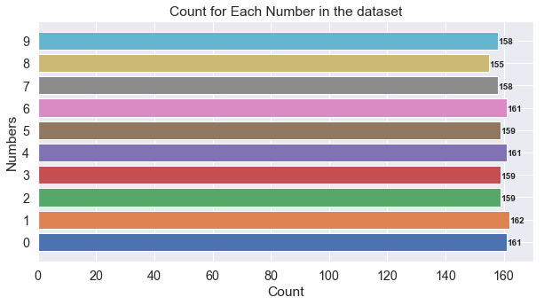

```python
numbers = np.arange(10) # y-axis : Numbers 0 to 9
count = sum(y).astype('int') # x-axis : Number of records for each number in the dataset
colors = sns.color_palette(None, 10) # 10 random colors
fig, ax = plt.subplots(figsize=(10,5))
ax.barh(numbers, count, color=colors)
plt.title('Count for Each Number in the dataset')
plt.xlabel('Count')
plt.ylabel('Numbers')
plt.yticks(numbers) # Display all the x coordinates

# Display Count at end of each bar
for i, v in enumerate(count):
    ax.text(v, i-0.15, str(v), fontweight='bold')
plt.show()
```

# Visualizing the data as images of numbers

```python
# Arranging the 256 columns as a 16x16 matrix
X[0].reshape((16,16))
```

```
array([[0., 0., 0., 0., 0., 0., 1., 1., 1., 1., 1., 1., 1., 1., 0., 0.],
       [0., 0., 0., 0., 0., 1., 1., 1., 1., 1., 1., 0., 1., 1., 0., 0.],
       [0., 0., 0., 0., 1., 1., 1., 1., 1., 1., 0., 0., 0., 1., 1., 0.],
       [0., 0., 0., 1., 1., 1., 1., 1., 0., 0., 0., 0., 1., 1., 1., 1.],
       [0., 0., 0., 1., 1., 1., 1., 0., 1., 1., 1., 1., 1., 1., 1., 0.],
       [0., 0., 0., 1., 1., 1., 0., 1., 1., 1., 1., 1., 0., 1., 1., 0.],
       [0., 0., 1., 1., 1., 1., 1., 1., 1., 1., 0., 0., 0., 1., 1., 0.],
       [0., 0., 1., 1., 1., 1., 1., 1., 0., 0., 0., 0., 1., 1., 0., 0.],
       [0., 1., 1., 1., 1., 1., 1., 0., 0., 0., 0., 0., 1., 1., 0., 0.],
       [0., 1., 1., 1., 1., 0., 0., 0., 0., 0., 0., 0., 1., 1., 0., 0.],
       [0., 1., 1., 1., 0., 0., 0., 0., 0., 0., 1., 1., 1., 0., 0., 0.],
       [1., 1., 1., 0., 0., 0., 0., 0., 0., 0., 1., 1., 0., 0., 0., 0.],
       [1., 1., 1., 1., 0., 0., 0., 0., 1., 1., 1., 1., 0., 0., 0., 0.],
       [1., 1., 1., 1., 0., 0., 0., 1., 1., 1., 0., 0., 0., 0., 0., 0.],
       [1., 0., 1., 1., 1., 1., 1., 1., 1., 0., 0., 0., 0., 0., 0., 0.],
       [0., 0., 0., 1., 1., 1., 1., 0., 0., 0., 0., 0., 0., 0., 0., 0.]])
```

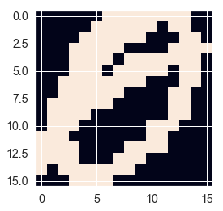

```python
# Visualizing the 16x16 matrix as image
plt.imshow(X[0].reshape((16,16)))
```

```python
# 16x16 matrix with Fortran-like index order
X[0].reshape((16,16), order = 'F')
```

```
array([[0., 0., 0., 0., 0., 0., 0., 0., 0., 0., 0., 1., 1., 1., 1., 0.],
       [0., 0., 0., 0., 0., 0., 0., 0., 1., 1., 1., 1., 1., 1., 0., 0.],
       [0., 0., 0., 0., 0., 0., 1., 1., 1., 1., 1., 1., 1., 1., 1., 0.],
       [0., 0., 0., 1., 1., 1., 1., 1., 1., 1., 1., 0., 1., 1., 1., 1.],
       [0., 0., 1., 1., 1., 1., 1., 1., 1., 1., 0., 0., 0., 0., 1., 1.],
       [0., 1., 1., 1., 1., 1., 1., 1., 1., 0., 0., 0., 0., 0., 1., 1.],
       [1., 1., 1., 1., 1., 0., 1., 1., 1., 0., 0., 0., 0., 0., 1., 1.],
       [1., 1., 1., 1., 0., 1., 1., 1., 0., 0., 0., 0., 0., 1., 1., 0.],
       [1., 1., 1., 0., 1., 1., 1., 0., 0., 0., 0., 0., 1., 1., 1., 0.],
       [1., 1., 1., 0., 1., 1., 1., 0., 0., 0., 0., 0., 1., 1., 0., 0.],
       [1., 1., 0., 0., 1., 1., 0., 0., 0., 0., 1., 1., 1., 0., 0., 0.],
       [1., 0., 0., 0., 1., 1., 0., 0., 0., 0., 1., 1., 1., 0., 0., 0.],
       [1., 1., 0., 1., 1., 0., 0., 1., 1., 1., 1., 0., 0., 0., 0., 0.],
       [1., 1., 1., 1., 1., 1., 1., 1., 1., 1., 0., 0., 0., 0., 0., 0.],
       [0., 0., 1., 1., 1., 1., 1., 0., 0., 0., 0., 0., 0., 0., 0., 0.],
       [0., 0., 0., 1., 0., 0., 0., 0., 0., 0., 0., 0., 0., 0., 0., 0.]])
```

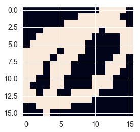

```python
# Visualizing the 16x16 matrix as image
plt.imshow(X[0].reshape((16,16), order = 'F'))
```

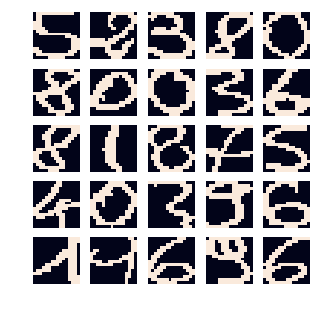

```python
# Visualizing the Image data. Visualizing 25 images from the data as a 5x5 matrix
_, axarr = plt.subplots(5,5,figsize=(5,5))
for i in range(5):
    for j in range(5):
        # Per iteration in the loop, picking one row randomly to display in our 5x5 matrix
        axarr[i,j].imshow(X[np.random.randint(X.shape[0])].reshape((16,16)))
        axarr[i,j].axis('off') #hiding the axis values for all the 25 images
```

```python
# Splitting the data
X_train, X_test, y_train, y_test = train_test_split(X, y, test_size = 0.3, random_state=SEED)
```

```python
# The number of columns for each image of a number is 256. Hence we will have 256 input layers in our Neural Network
n_cols = X.shape[1]
n_cols
```

```
256
```

```python
# Number of possible columns which can have 1 is '10'. Hence we will have 10 output layers in our Neural Network.
n_categories = y.shape[1]
n_categories
```

```
10
```

# Training network with 50 epochs

```python
# Initiating the Neural Network model
model = Sequential()

# Add the first hidden layer which connects all the input layer nodes and a Bias Unit having value 1
model.add(Dense(100, activation='sigmoid', input_shape = (n_cols,), use_bias=True, bias_initializer='ones'))

# Output layer with a Bias Unit having value 1
model.add(Dense(n_categories, activation='sigmoid', use_bias=True, bias_initializer='ones'))
# https://towardsdatascience.com/activation-functions-neural-networks-1cbd9f8d91d6

# Create SGD optimizer with specified learning rate: my_optimizer
my_optimizer = SGD(lr=0.1)

# Compile the model
model.compile(optimizer=my_optimizer, loss='categorical_crossentropy', metrics=['accuracy'])

# For Stopping optimization when the validation loss hasn't improved for patience epochs. In this case 2 epochs
early_stopping_monitor = EarlyStopping(patience=2)

# Fit the model
history = model.fit(X_train, y_train, validation_split=0.3, epochs=50, verbose=2, callbacks=[early_stopping_monitor])
history

print('Train accuracy:',max(history.history['acc']))
print('Train loss:',min(history.history['loss']))

# https://www.quora.com/What-is-the-difference-between-keras-evaluate-and-keras-predict
# keras.evaluate() is for evaluating your trained model. Its output is accuracy or loss, not prediction to your input data.
score = model.evaluate(X_test, y_test)
print('Test accuracy:', score[1])
print('Test loss:', score[0])

# keras.predict() actually predicts, and its output is target value, predicted from your input data.
# Predicted values for each number and for each record
y_pred = model.predict(X_test)
```

```
WARNING:tensorflow:From C:\ProgramData\Anaconda3\lib\site-packages\tensorflow\python\framework\op_def_library.py:263: colocate_with (from tensorflow.python.framework.ops) is deprecated and will be removed in a future version.
Instructions for updating:
Colocations handled automatically by placer.
WARNING:tensorflow:From C:\ProgramData\Anaconda3\lib\site-packages\tensorflow\python\ops\math_ops.py:3066: to_int32 (from tensorflow.python.ops.math_ops) is deprecated and will be removed in a future version.
Instructions for updating:
Use tf.cast instead.
Train on 780 samples, validate on 335 samples
 - 1s - loss: 2.3114 - acc: 0.0987 - val_loss: 2.3030 - val_acc: 0.0776
 - 0s - loss: 2.2956 - acc: 0.0987 - val_loss: 2.2992 - val_acc: 0.0776
 - 0s - loss: 2.2865 - acc: 0.1000 - val_loss: 2.2909 - val_acc: 0.0985
 - 0s - loss: 2.2754 - acc: 0.1308 - val_loss: 2.2792 - val_acc: 0.1313
 - 0s - loss: 2.2586 - acc: 0.1410 - val_loss: 2.2647 - val_acc: 0.1940
 - 0s - loss: 2.2268 - acc: 0.2282 - val_loss: 2.2212 - val_acc: 0.2179
 - 0s - loss: 2.1602 - acc: 0.2833 - val_loss: 2.1084 - val_acc: 0.3164
 - 0s - loss: 2.0192 - acc: 0.4731 - val_loss: 1.9544 - val_acc: 0.5134
 - 0s - loss: 1.8052 - acc: 0.6551 - val_loss: 1.7553 - val_acc: 0.5254
 - 0s - loss: 1.5898 - acc: 0.7064 - val_loss: 1.5505 - val_acc: 0.6418
 - 0s - loss: 1.4021 - acc: 0.7641 - val_loss: 1.3667 - val_acc: 0.7612
 - 0s - loss: 1.2098 - acc: 0.8154 - val_loss: 1.2120 - val_acc: 0.7881
 - 0s - loss: 1.0576 - acc: 0.8449 - val_loss: 1.1055 - val_acc: 0.7910
 - 0s - loss: 0.9293 - acc: 0.8577 - val_loss: 0.9864 - val_acc: 0.8239
 - 0s - loss: 0.8231 - acc: 0.8782 - val_loss: 0.9443 - val_acc: 0.7642
 - 0s - loss: 0.7398 - acc: 0.8872 - val_loss: 0.8625 - val_acc: 0.7910
 - 0s - loss: 0.6678 - acc: 0.8923 - val_loss: 0.7859 - val_acc: 0.8239
 - 0s - loss: 0.6139 - acc: 0.8962 - val_loss: 0.7238 - val_acc: 0.8418
 - 0s - loss: 0.5604 - acc: 0.9051 - val_loss: 0.7019 - val_acc: 0.8448
 - 0s - loss: 0.5193 - acc: 0.9141 - val_loss: 0.6653 - val_acc: 0.8418
 - 0s - loss: 0.4846 - acc: 0.9167 - val_loss: 0.6330 - val_acc: 0.8478
 - 0s - loss: 0.4564 - acc: 0.9192 - val_loss: 0.6000 - val_acc: 0.8537
 - 0s - loss: 0.4255 - acc: 0.9205 - val_loss: 0.5856 - val_acc: 0.8597
 - 0s - loss: 0.4014 - acc: 0.9218 - val_loss: 0.5453 - val_acc: 0.8597
 - 0s - loss: 0.3802 - acc: 0.9256 - val_loss: 0.5362 - val_acc: 0.8567
 - 0s - loss: 0.3574 - acc: 0.9295 - val_loss: 0.5201 - val_acc: 0.8627
 - 0s - loss: 0.3417 - acc: 0.9346 - val_loss: 0.5070 - val_acc: 0.8657
 - 0s - loss: 0.3250 - acc: 0.9282 - val_loss: 0.5011 - val_acc: 0.8716
 - 0s - loss: 0.3090 - acc: 0.9423 - val_loss: 0.4712 - val_acc: 0.8836
 - 0s - loss: 0.2984 - acc: 0.9372 - val_loss: 0.4884 - val_acc: 0.8567
 - 0s - loss: 0.2848 - acc: 0.9436 - val_loss: 0.4521 - val_acc: 0.8866
 - 0s - loss: 0.2710 - acc: 0.9513 - val_loss: 0.4537 - val_acc: 0.8806
 - 0s - loss: 0.2601 - acc: 0.9462 - val_loss: 0.4427 - val_acc: 0.8806
 - 0s - loss: 0.2495 - acc: 0.9513 - val_loss: 0.4360 - val_acc: 0.8896
 - 0s - loss: 0.2400 - acc: 0.9538 - val_loss: 0.4213 - val_acc: 0.8985
 - 0s - loss: 0.2323 - acc: 0.9551 - val_loss: 0.4209 - val_acc: 0.8925
 - 0s - loss: 0.2242 - acc: 0.9603 - val_loss: 0.4164 - val_acc: 0.8955
 - 0s - loss: 0.2162 - acc: 0.9590 - val_loss: 0.4104 - val_acc: 0.8896
 - 0s - loss: 0.2086 - acc: 0.9603 - val_loss: 0.3997 - val_acc: 0.8925
 - 0s - loss: 0.2006 - acc: 0.9615 - val_loss: 0.3972 - val_acc: 0.8925
 - 0s - loss: 0.1942 - acc: 0.9667 - val_loss: 0.3925 - val_acc: 0.8896
 - 0s - loss: 0.1878 - acc: 0.9744 - val_loss: 0.3894 - val_acc: 0.8896
 - 0s - loss: 0.1819 - acc: 0.9679 - val_loss: 0.3802 - val_acc: 0.8955
 - 0s - loss: 0.1772 - acc: 0.9718 - val_loss: 0.3775 - val_acc: 0.8985
 - 0s - loss: 0.1705 - acc: 0.9718 - val_loss: 0.3745 - val_acc: 0.8985
 - 0s - loss: 0.1650 - acc: 0.9718 - val_loss: 0.3713 - val_acc: 0.8985
 - 0s - loss: 0.1601 - acc: 0.9782 - val_loss: 0.3727 - val_acc: 0.8955
 - 0s - loss: 0.1560 - acc: 0.9756 - val_loss: 0.3676 - val_acc: 0.8985
 - 0s - loss: 0.1507 - acc: 0.9782 - val_loss: 0.3643 - val_acc: 0.9045
 - 0s - loss: 0.1456 - acc: 0.9821 - val_loss: 0.3602 - val_acc: 0.8955
Train accuracy: 0.982051282051282
Train loss: 0.14561323523521424
Test accuracy: 0.9079497892986281
Test loss: 0.3258736048782221
```

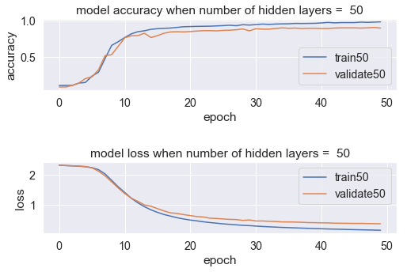

```python
# Reference : https://nextjournal.com/gkoehler/digit-recognition-with-keras
# Plotting the accuracy : Epoch vs Accuracy
def plot_graph(history, n):
    fig = plt.figure(figsize=(8,5))
    plt.subplot(2,1,1)
    plt.plot(history.history['acc'])
    plt.plot(history.history['val_acc'])
    plt.title('model accuracy when number of hidden layers =  '+str(n))
    plt.ylabel('accuracy')
    plt.xlabel('epoch')
    plt.legend(['train'+str(n), 'validate'+str(n)], loc='lower right')
    fig.subplots_adjust(hspace=1)

    plt.subplot(2,1,2)
    plt.plot(history.history['loss'])
    plt.plot(history.history['val_loss'])
    plt.title('model loss when number of hidden layers =  '+str(n))
    plt.ylabel('loss')
    plt.xlabel('epoch')
    plt.legend(['train'+str(n), 'validate'+str(n)], loc='upper right')
    plt.show()
    return plt.tight_layout()

plot_graph(history,50)
```

# Transforming the y_values for Confusion Matrix

```python
print(y_pred[0])
```

```
[6.9439411e-06 1.7273426e-04 8.5473061e-05 7.8563005e-02 7.9840422e-05
 5.1897764e-04 3.5256147e-05 5.8835745e-04 1.0865927e-04 1.5741587e-04]
```

The predicted values are sigmoid values for each number, the maximum of which is the prediction.

```python
# Sample code : https://www.kaggle.com/abhishekkrsingh/keras-101-mnist-dataset
# Changing the one hot encoded columns to a single column which has 10 categories : 0 to 9
# Converting the 10 columns predicted values of test data to 1 categorical column(array)
prediction = np.argmax(y_pred, axis = 1)
print(prediction)
```

```
[3 7 1 7 5 8 5 9 9 6 9 4 0 1 2 3 1 8 1 6 1 8 3 3 9 3 5 1 3 7 0 9 4 9 5 4 7
 0 8 7 9 2 8 9 3 0 7 1 5 5 2 0 9 1 1 7 9 8 9 5 7 0 6 5 6 0 0 3 7 7 1 8 3 6
 1 7 1 3 7 1 8 1 9 1 8 2 1 1 5 1 2 6 9 8 9 4 5 4 4 5 9 2 4 6 4 6 8 4 6 4 0
 6 1 4 6 4 4 2 7 1 8 3 2 7 1 0 9 0 0 1 1 7 0 2 0 0 9 3 8 1 6 4 1 4 5 4 5 5
 6 6 0 2 6 7 5 5 3 8 4 3 4 4 7 1 9 7 1 9 2 4 5 4 1 3 4 0 3 4 9 9 3 5 8 3 3
 2 6 4 5 2 2 0 2 2 5 9 8 1 1 8 9 0 6 4 5 2 1 4 1 1 7 8 6 0 4 5 9 2 9 1 0 8
 7 5 1 8 9 4 0 1 7 6 9 0 2 1 2 0 5 8 0 6 2 0 2 5 7 3 4 5 8 1 9 5 0 2 4 8 4
 4 4 4 4 5 3 5 4 4 4 1 8 8 4 6 5 0 6 4 3 6 9 2 0 6 3 4 4 4 3 5 9 1 1 8 6 9
 8 1 1 4 9 2 4 2 9 3 9 9 6 5 3 1 0 5 7 3 0 0 3 2 7 7 8 1 0 4 5 6 9 7 1 9 3
 8 2 6 4 3 9 0 6 2 4 0 6 7 3 9 4 6 8 6 6 0 5 3 1 4 7 6 9 7 6 9 4 9 5 6 2 6
 8 3 4 0 9 4 5 1 8 3 6 1 7 8 6 8 9 1 8 1 4 9 2 2 2 0 0 7 3 3 2 0 2 0 5 3 8
 6 9 5 5 8 2 8 4 4 3 0 3 4 8 6 6 6 3 8 2 8 5 0 6 1 9 9 6 4 6 5 6 8 8 8 5 9
 7 3 3 1 5 7 9 2 3 8 8 2 7 3 0 2 4 4 2 9 7 7 8 3 8 6 6 1 2 0 0 5 9 6]
```

```python
# Converting the 10 columns actual test data to 1 categorical column(array)
actual = np.argmax(y_test, axis = 1)
print(actual)
```

```
[3 5 1 7 5 8 5 9 9 8 9 7 0 1 2 3 4 8 1 6 4 8 3 3 9 3 5 9 3 7 0 9 4 9 5 4 7
 0 8 7 9 2 8 9 3 0 7 1 5 5 8 0 9 1 1 7 9 3 5 5 7 0 6 5 6 0 0 3 7 7 1 8 3 6
 3 1 1 9 7 1 8 1 9 1 8 2 2 1 5 1 2 6 9 8 9 4 5 4 4 5 9 2 4 6 4 6 8 4 6 4 0
 6 1 4 6 4 4 2 1 1 8 3 2 7 1 0 9 0 0 1 2 7 0 2 0 0 9 9 8 8 6 4 1 4 0 4 5 5
 6 6 0 2 6 5 5 5 3 2 4 3 4 4 4 1 9 7 1 9 2 4 5 4 1 3 4 0 3 4 9 9 3 5 8 3 3
 2 6 4 5 2 2 0 2 2 5 9 8 1 1 8 9 0 6 4 5 2 1 4 1 8 7 8 6 0 4 5 9 2 3 1 0 8
 7 5 1 8 9 4 0 1 7 6 9 0 2 1 2 0 5 8 0 6 2 0 2 5 7 3 4 5 8 1 9 8 0 2 4 8 4
 1 2 2 4 5 3 5 4 4 4 1 2 8 4 6 5 0 6 4 3 6 9 2 0 6 9 4 4 4 8 5 9 1 1 8 6 8
 8 1 1 4 9 2 4 2 9 3 9 9 6 5 3 1 0 1 7 3 0 9 3 2 7 7 8 1 0 4 5 6 9 7 1 3 3
 8 2 6 4 3 9 0 6 2 4 0 6 7 3 9 4 6 8 6 6 0 5 3 1 6 7 6 4 7 6 9 4 5 5 6 2 6
 8 3 4 0 9 4 5 9 8 1 6 1 7 8 6 8 9 1 8 1 4 9 2 2 2 0 0 7 3 3 2 0 2 0 5 3 8
 6 9 5 5 8 2 8 4 4 3 0 3 4 8 6 5 6 3 8 2 8 5 0 6 4 9 9 6 4 6 5 6 8 8 8 5 9
 7 3 3 1 5 1 9 8 3 7 8 2 7 3 0 2 4 4 2 9 7 7 8 3 8 6 6 1 2 0 0 5 9 6]
```

```python
print(y_test[0])
print(actual[0])
```

```
[0. 0. 0. 1. 0. 0. 0. 0. 0. 0.]
3
```

```python
print(y_pred[0])
print(prediction[0])
```

```
[6.9439411e-06 1.7273426e-04 8.5473061e-05 7.8563005e-02 7.9840422e-05
 5.1897764e-04 3.5256147e-05 5.8835745e-04 1.0865927e-04 1.5741587e-04]
3
```

```
Below is the image of the selected number:
```

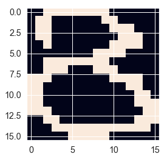

```
Actual values of each number for selected number:
 [0. 0. 0. 0. 0. 0. 0. 0. 1. 0.]

Actual Number:  8

Predicted sigmoid values of each number for selected number:
 [2.1040440e-04 1.4370680e-04 7.2181225e-04 3.3627450e-03 8.3535910e-05
 4.5031309e-05 1.5959144e-04 6.0975552e-05 1.6002059e-03 6.6205859e-04]

Predicted Number:  3
```

```python
i=288
print("Below is the image of the selected number:")
plt.imshow(X_test[i].reshape((16,16))); plt.show()
print('Actual values of each number for selected number:\n', y_test[i])
print('\nActual Number: ', actual[i])
print('\nPredicted sigmoid values of each number for selected number:\n', y_pred[i])
print('\nPredicted Number: ', prediction[i])
```

```python
cm = confusion_matrix(actual, prediction)
cm
```

```
array([[45,  0,  0,  0,  0,  1,  0,  0,  0,  0],
       [ 0, 44,  0,  1,  1,  1,  0,  3,  0,  0],
       [ 0,  2, 40,  0,  2,  0,  0,  0,  2,  0],
       [ 0,  1,  0, 40,  0,  0,  0,  0,  1,  2],
       [ 0,  3,  0,  0, 55,  0,  0,  1,  0,  1],
       [ 0,  0,  0,  0,  0, 42,  1,  2,  0,  2],
       [ 0,  0,  0,  0,  1,  0, 48,  0,  0,  0],
       [ 0,  0,  0,  0,  1,  0,  0, 30,  1,  0],
       [ 0,  2,  2,  1,  0,  1,  1,  0, 44,  1],
       [ 1,  2,  0,  3,  0,  0,  0,  0,  0, 46]], dtype=int64)
```

```
[Text(21.1,0.5,'Actual'), Text(0.5,17.5,'Predicted')]
```

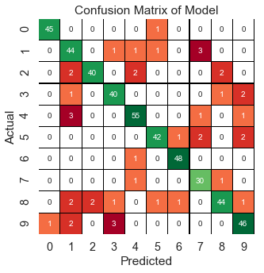

```python
# Plotting the Confusion Matrix for each understanding
fig = plt.figure(figsize=(5,5))
ax = plt.axes()
sns.heatmap(cm,
            annot=True, # Show values of each cell in the heatmap
            fmt="1.0f", # or "d"
            cmap=ListedColormap(['#ffffff','#f46d43','#d73027','#d73027','#a50026','#a50026','#a50026','#a50026','#a50026','#ffffbf','#ffffbf','#ffffbf','#ffffbf','#d9ef8b','#d9ef8b','#d9ef8b','#d9ef8b','#d9ef8b','#d9ef8b','#d9ef8b','#d9ef8b','#d9ef8b','#d9ef8b','#d9ef8b','#d9ef8b','#d9ef8b','#d9ef8b','#d9ef8b','#d9ef8b','#d9ef8b','#a6d96a','#a6d96a','#a6d96a','#a6d96a','#a6d96a','#a6d96a','#a6d96a','#a6d96a','#a6d96a','#a6d96a','#a6d96a','#a6d96a','#a6d96a','#a6d96a','#a6d96a','#a6d96a','#a6d96a','#66bd63','#66bd63','#66bd63','#66bd63','#66bd63','#66bd63','#66bd63','#66bd63','#66bd63','#66bd63','#66bd63','#66bd63','#66bd63','#66bd63','#66bd63','#66bd63','#66bd63','#1a9850','#1a9850','#1a9850','#1a9850','#1a9850','#1a9850','#1a9850','#1a9850','#1a9850','#1a9850','#1a9850','#1a9850','#1a9850','#1a9850','#1a9850','#1a9850','#1a9850','#006837','#006837','#006837','#006837','#006837','#006837','#006837','#006837','#006837','#006837','#006837','#006837','#006837','#006837','#006837','#006837','#006837']),
            linewidths=0.1, # width of border
            linecolor='black', # border color
            cbar=False, # hide range bar
            square=True) # Make the Confusion Matrix Look like a square
ax.set_title('Confusion Matrix of Model')
ax.set(xlabel='Predicted', ylabel='Actual') # Change X and Y axis labels
```

```python
# Precision and Recall Statistics for each number
print(classification_report(actual, prediction))
```

```
              precision    recall  f1-score   support

           0       0.98      0.98      0.98        46
           1       0.81      0.88      0.85        50
           2       0.95      0.87      0.91        46
           3       0.89      0.91      0.90        44
           4       0.92      0.92      0.92        60
           5       0.93      0.89      0.91        47
           6       0.96      0.98      0.97        49
           7       0.83      0.94      0.88        32
           8       0.92      0.85      0.88        52
           9       0.88      0.88      0.88        52

   micro avg       0.91      0.91      0.91       478
   macro avg       0.91      0.91      0.91       478
weighted avg       0.91      0.91      0.91       478
```

```python
accuracy_score(actual, prediction)
```

```
0.9079497907949791
```

# Function to develop Neural Network based on given configuration

```python
def run_neural_network(X_train, y_train, X_test, y_test, hidden_layers_count, learning_rate, epoch_count):
    print('\nTesting model with number of hidden layers = ' + str(hidden_layers_count) + ', learning rate = ' + str(learning_rate) +   ', no. of epochs = ' + str(epoch_count) + '\n')

    # Initiating the Neural Network model
    model = Sequential()

    # Add the first hidden layer which connects all the input layer nodes and a Bias Unit having value 1
    model.add(Dense(hidden_layers_count,
                    activation='sigmoid',
                    input_shape = (n_cols,),
                    use_bias=True,
                    bias_initializer='ones'))

    # Output layer with a Bias Unit having value 1
    model.add(Dense(n_categories,
                    activation='sigmoid',
                    use_bias=True,
                    bias_initializer='ones'))
    # https://towardsdatascience.com/activation-functions-neural-networks-1cbd9f8d91d6

    # Create SGD optimizer with specified learning rate: my_optimizer
    my_optimizer = SGD(lr=learning_rate)

    # Compile the model
    model.compile(optimizer=my_optimizer, loss='categorical_crossentropy', metrics=['accuracy'])

    # For Stopping optimization when the validation loss hasn't improved for patience epochs. In this case 2 epochs
    early_stopping_monitor = EarlyStopping(patience=2)

    # Fit the model
    history = model.fit(X_train, y_train, validation_split=0.3, epochs=epoch_count, verbose=0, callbacks=[early_stopping_monitor])

    print('Train accuracy:',max(history.history['acc']))
    print('Train loss:',min(history.history['loss']))

    # keras.evaluate() is for evaluating your trained model. Its output is accuracy or loss, not prediction to your input data.
    score = model.evaluate(X_test, y_test, verbose=0)
    print('Test accuracy:', score[1])
    print('Test loss:', score[0])

    # Plot the graph: Epochs vs Accuracy
    plot_graph(history, hidden_layers_count)

    # Predicted values for each number and for each record
    y_pred = model.predict(X_test)

    #Getting the value of actual and predicted number for confusion matrix
    actual = np.argmax(y_test, axis = 1)  # Since each prediction is a one hot encoded array
    prediction = np.argmax(y_pred, axis = 1)  # Since each prediction is a one hot encoded array

    # Finding the Confusion Matrix
    cm = confusion_matrix(actual, prediction)

    # Visualizing Confusion Matrix
    plot_confusion_matrix(cm)

    # Print the Classification Report
    print('Classification Report: \n'+classification_report(actual, prediction))

    #Print Accuracy Score
    test_accuracy = accuracy_score(actual, prediction)
    print('Accuracy Score of the model: ' + str(test_accuracy))
```

```python
# Plotting the Confusion Matrix for each understanding
def plot_confusion_matrix(cm):
    fig = plt.figure(figsize=(5,5))
    ax = plt.axes()
    sns.heatmap(cm,
                annot=True, # Show values of each cell in the heatmap
                fmt="1.0f", # or "d"
                cmap=ListedColormap(['#ffffff','#f46d43','#f46d43','#f46d43','#d73027','#d73027','#d73027','#d73027','#d73027','#d73027','#a50026','#a50026','#a50026','#a50026','#a50026','#ffffbf','#ffffbf','#ffffbf','#ffffbf','#d9ef8b','#d9ef8b','#d9ef8b','#d9ef8b','#d9ef8b','#d9ef8b','#d9ef8b','#d9ef8b','#d9ef8b','#d9ef8b','#d9ef8b','#d9ef8b','#d9ef8b','#d9ef8b','#d9ef8b','#d9ef8b','#d9ef8b','#a6d96a','#a6d96a','#a6d96a','#a6d96a','#a6d96a','#a6d96a','#a6d96a','#a6d96a','#a6d96a','#a6d96a','#a6d96a','#a6d96a','#a6d96a','#a6d96a','#a6d96a','#a6d96a','#a6d96a','#66bd63','#66bd63','#66bd63','#66bd63','#66bd63','#66bd63','#66bd63','#66bd63','#66bd63','#66bd63','#66bd63','#66bd63','#66bd63','#66bd63','#66bd63','#66bd63','#66bd63','#1a9850','#1a9850','#1a9850','#1a9850','#1a9850','#1a9850','#1a9850','#1a9850','#1a9850','#1a9850','#1a9850','#1a9850','#1a9850','#1a9850','#1a9850','#1a9850','#1a9850','#006837','#006837','#006837','#006837','#006837','#006837','#006837','#006837','#006837','#006837','#006837','#006837','#006837','#006837','#006837','#006837','#006837']),
                linewidths=0.1, # width of border
                linecolor='black', # border color
                cbar=False, # hide range bar
                square=True) # Make the Confusion Matrix Look like a square
    ax.set_title('Confusion Matrix of Model')
    ax.set(xlabel='Predicted', ylabel='Actual') # Change X and Y axis labels
    plt.show()
    return ax
```

```python
# To display the values in non-scientific notation
# https://www.w3resource.com/python-exercises/numpy/python-numpy-exercise-84.php
np.set_printoptions(suppress=True)
```

### Experimenting with different number of hidden layers : 20, 50, 100

```
Testing model with number of hidden layers = 20, learning rate = 0.1, no. of epochs = 50

Train accuracy: 0.95
Train loss: 0.335576892663271
Test accuracy: 0.891213387624988
Test loss: 0.5044363414143918
```

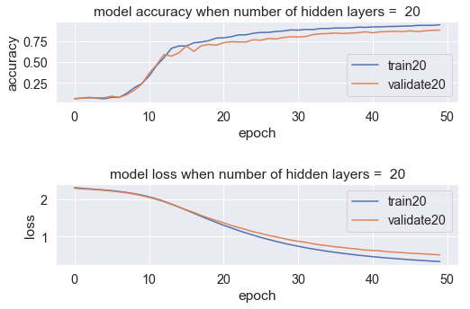

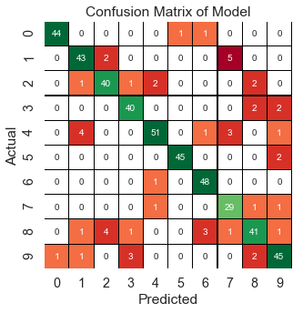

```
Classification Report:
              precision    recall  f1-score   support

           0       0.98      0.96      0.97        46
           1       0.86      0.86      0.86        50
           2       0.87      0.87      0.87        46
           3       0.89      0.91      0.90        44
           4       0.93      0.85      0.89        60
           5       0.98      0.96      0.97        47
           6       0.91      0.98      0.94        49
           7       0.76      0.91      0.83        32
           8       0.85      0.79      0.82        52
           9       0.87      0.87      0.87        52

   micro avg       0.89      0.89      0.89       478
   macro avg       0.89      0.89      0.89       478
weighted avg       0.89      0.89      0.89       478

Accuracy Score of the model: 0.891213389121339
```

```python
# Neural Network model with 20 units in the hidden layer
run_neural_network(X_train, y_train, X_test, y_test, hidden_layers_count = 20, learning_rate = 0.1, epoch_count = 50)
```

```
Testing model with number of hidden layers = 50, learning rate = 0.1, no. of epochs = 50

Train accuracy: 0.9769230769230769
Train loss: 0.17458962423679156
Test accuracy: 0.9058577388400313
Test loss: 0.35069324456498213
```

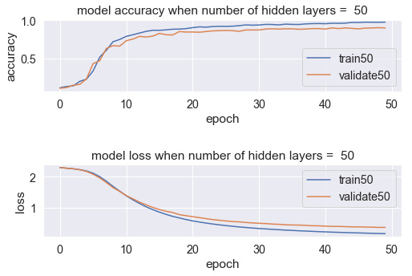

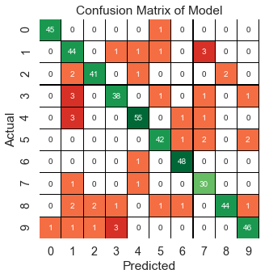

```
Classification Report:
              precision    recall  f1-score   support

           0       0.98      0.98      0.98        46
           1       0.79      0.88      0.83        50
           2       0.93      0.89      0.91        46
           3       0.88      0.86      0.87        44
           4       0.93      0.92      0.92        60
           5       0.91      0.89      0.90        47
           6       0.94      0.98      0.96        49
           7       0.81      0.94      0.87        32
           8       0.96      0.85      0.90        52
           9       0.92      0.88      0.90        52

   micro avg       0.91      0.91      0.91       478
   macro avg       0.91      0.91      0.91       478
weighted avg       0.91      0.91      0.91       478

Accuracy Score of the model: 0.9058577405857741
```

```python
# Neural Network model with 50 units in the hidden layer
run_neural_network(X_train, y_train, X_test, y_test, hidden_layers_count = 50, learning_rate = 0.1, epoch_count = 50)
```

```
Testing model with number of hidden layers = 100, learning rate = 0.1, no. of epochs = 50

Train accuracy: 0.9846153846153847
Train loss: 0.14890033182425377
Test accuracy: 0.914225941671986
Test loss: 0.3286462194251216
```

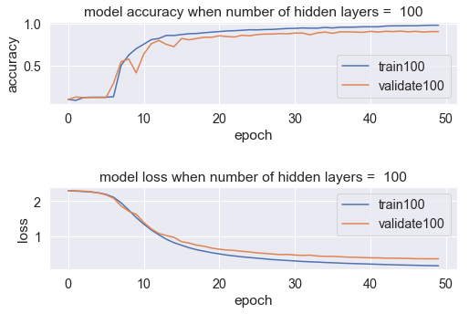

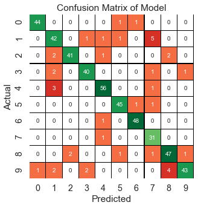

```
Classification Report:
              precision    recall  f1-score   support

           0       0.98      0.96      0.97        46
           1       0.82      0.84      0.83        50
           2       0.95      0.89      0.92        46
           3       0.93      0.91      0.92        44
           4       0.93      0.93      0.93        60
           5       0.94      0.96      0.95        47
           6       0.96      0.98      0.97        49
           7       0.78      0.97      0.86        32
           8       0.89      0.90      0.90        52
           9       0.96      0.83      0.89        52

   micro avg       0.91      0.91      0.91       478
   macro avg       0.91      0.92      0.91       478
weighted avg       0.92      0.91      0.91       478

Accuracy Score of the model: 0.9142259414225942
```

```python
# Neural Network model with 100 units in the hidden layer
run_neural_network(X_train, y_train, X_test, y_test, hidden_layers_count = 100, learning_rate = 0.1, epoch_count = 50)
```

```
Testing model with number of hidden layers = 200, learning rate = 0.1, no. of epochs = 50

Train accuracy: 0.9589743592800238
Train loss: 0.2133579665269607
Test accuracy: 0.8995815904569426
Test loss: 0.39460069464839154
```

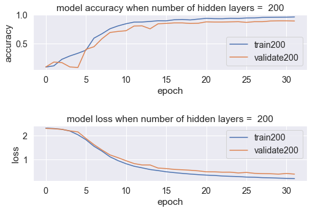

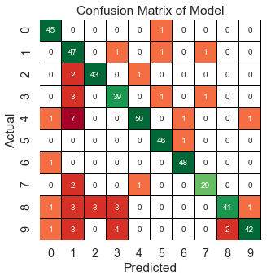

```
Classification Report:
              precision    recall  f1-score   support

           0       0.92      0.98      0.95        46
           1       0.70      0.94      0.80        50
           2       0.93      0.93      0.93        46
           3       0.83      0.89      0.86        44
           4       0.96      0.83      0.89        60
           5       0.94      0.98      0.96        47
           6       0.96      0.98      0.97        49
           7       0.94      0.91      0.92        32
           8       0.95      0.79      0.86        52
           9       0.95      0.81      0.88        52

   micro avg       0.90      0.90      0.90       478
   macro avg       0.91      0.90      0.90       478
weighted avg       0.91      0.90      0.90       478

Accuracy Score of the model: 0.899581589958159
```

```python
# Neural Network model with 200 units in the hidden layer.
# This is to check if we can keep on increasing the number of hidden layers to increase the accuracy.
run_neural_network(X_train, y_train, X_test, y_test, hidden_layers_count = 200, learning_rate = 0.1, epoch_count = 50)
```

# Plot of both training and test accuracy as a function of epoch number:

Since the above graphs are of epoch accuracies of Train and Validation data, created a new function which prints the Epoch vs Accuracy graph for Train and **Test** data.

```python
def epoch_vs_accuracy(X_train, y_train, X_test, y_test, hidden_layers_count, learning_rate, epoch_count):
    print('\nTesting model with number of hidden layers = ' + str(hidden_layers_count) + ', learning rate = ' + str(learning_rate) +   ', no. of epochs = ' + str(epoch_count) + '\n')

    # Initiating the Neural Network model
    model = Sequential()

    # Add the first hidden layer which connects all the input layer nodes and a Bias Unit having value 1
    model.add(Dense(hidden_layers_count,
                    activation='sigmoid',
                    input_shape = (n_cols,),
                    use_bias=True,
                    bias_initializer='ones'))

    # Output layer with a Bias Unit having value 1
    model.add(Dense(n_categories,
                    activation='sigmoid',
                    use_bias=True,
                    bias_initializer='ones'))
    # https://towardsdatascience.com/activation-functions-neural-networks-1cbd9f8d91d6

    # Create SGD optimizer with specified learning rate: my_optimizer
    my_optimizer = SGD(lr=learning_rate)

    # Compile the model
    model.compile(optimizer=my_optimizer, loss='categorical_crossentropy', metrics=['accuracy'])

    # For Stopping optimization when the validation loss hasn't improved for patience epochs. In this case 2 epochs
    early_stopping_monitor = EarlyStopping(patience=2)

    # Fit the model
    history = model.fit(X_train, y_train, validation_data=(X_test, y_test), epochs=epoch_count, verbose=0, callbacks=[early_stopping_monitor])

    # Plot the graph: Epochs vs Accuracy
    fig = plt.figure(figsize=(8,5))
    plt.subplot(2,1,1)
    plt.plot(history.history['acc'])
    plt.plot(history.history['val_acc'])
    plt.title('model accuracy when number of hidden layers =  '+str(hidden_layers_count))
    plt.ylabel('accuracy')
    plt.xlabel('epoch')
    plt.legend(['train'+str(hidden_layers_count), 'test'+str(hidden_layers_count)], loc='lower right')
    fig.subplots_adjust(hspace=1)

    plt.subplot(2,1,2)
    plt.plot(history.history['loss'])
    plt.plot(history.history['val_loss'])
    plt.title('model loss when number of hidden layers =  '+str(hidden_layers_count))
    plt.ylabel('loss')
    plt.xlabel('epoch')
    plt.legend(['train'+str(hidden_layers_count), 'test'+str(hidden_layers_count)], loc='upper right')
    plt.show()
    return plt.tight_layout()
```

```
Testing model with number of hidden layers = 20, learning rate = 0.1, no. of epochs = 50
```

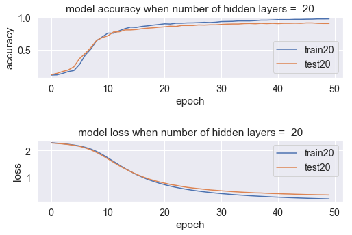

```python
# Epoch vs Accuracy on training and testing data when there are 20 units in the hidden layer
epoch_vs_accuracy(X_train, y_train, X_test, y_test, hidden_layers_count = 20, learning_rate = 0.1, epoch_count = 50)
```

```
Testing model with number of hidden layers = 50, learning rate = 0.1, no. of epochs = 50
```

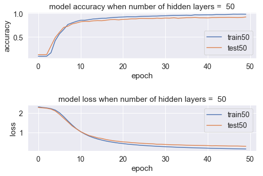

```python
# Epoch vs Accuracy on training and testing data when there are 50 units in the hidden layer
epoch_vs_accuracy(X_train, y_train, X_test, y_test, hidden_layers_count = 50, learning_rate = 0.1, epoch_count = 50)
```

```
Testing model with number of hidden layers = 100, learning rate = 0.1, no. of epochs = 50
```

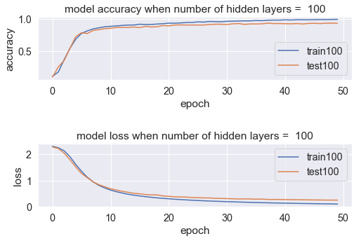

```python
# Epoch vs Accuracy on training and testing data when there are 100 units in the hidden layer
epoch_vs_accuracy(X_train, y_train, X_test, y_test, hidden_layers_count = 100, learning_rate = 0.1, epoch_count = 50)
```

```
Testing model with number of hidden layers = 200, learning rate = 0.1, no. of epochs = 50
```

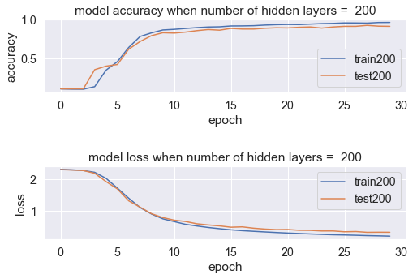

```python
# Epoch vs Accuracy on training and testing data when there are 200 units in the hidden layer
epoch_vs_accuracy(X_train, y_train, X_test, y_test, hidden_layers_count = 200, learning_rate = 0.1, epoch_count = 50)
```

# Effect of number of hidden units on the final accuracy on the test data:

As the number of units in the hidden layer increases, the Accuracy increases though not a significant amount. But it doesn't mean that increasing the number of units in the hidden layer will always increase the Accuracy. Just to prove that, I tried a large number of neurons in the hidden layer say 200 which reduces the accuracy. Increasing the number of units in the hidden layer increases the computational cost and may not be used when there is not considerable increase in the accuracy.

# Finding the effect of number of hidden units on the number of epochs needed for training to converge:

```python
def hidden_vs_epoch(X_train, y_train, X_test, y_test, hidden_layers_count, learning_rate, epoch_count):
    print('\nTesting model with number of hidden layers = ' + str(hidden_layers_count) +   ', no. of epochs = ' + str(epoch_count) + '\n')

    # Initiating the Neural Network model
    model = Sequential()

    # Add the first hidden layer which connects all the input layer nodes and a Bias Unit having value 1
    model.add(Dense(hidden_layers_count,
                    activation='sigmoid',
                    input_shape = (n_cols,),
                    use_bias=True,
                    bias_initializer='ones'))

    # Output layer with a Bias Unit having value 1
    model.add(Dense(n_categories,
                    activation='sigmoid',
                    use_bias=True,
                    bias_initializer='ones'))
    # https://towardsdatascience.com/activation-functions-neural-networks-1cbd9f8d91d6

    # Create SGD optimizer with specified learning rate: my_optimizer
    my_optimizer = SGD(lr=learning_rate)

    # Compile the model
    model.compile(optimizer=my_optimizer, loss='categorical_crossentropy', metrics=['accuracy'])

    # For Stopping optimization when the validation loss hasn't improved for patience epochs. In this case 2 epochs
    early_stopping_monitor = EarlyStopping(patience=2)

    # Fit the model
    history = model.fit(X_train, y_train, validation_split=0.3, epochs=epoch_count, verbose=0, callbacks=[early_stopping_monitor])

    #Finding the number of epochs
    n_epochs = len(history.history['loss'])
    print('Number of epochs:', n_epochs)
```

```python
# Finding the Number of Epochs needed for Neural Network model with 20 units in the hidden layer.
hidden_vs_epoch(X_train, y_train, X_test, y_test, hidden_layers_count = 20, learning_rate = 0.1, epoch_count = 200)
```

```
Testing model with number of hidden layers = 20, no. of epochs = 200

Number of epochs: 122
```

```python
# Finding the Number of Epochs needed for Neural Network model with 50 units in the hidden layer.
hidden_vs_epoch(X_train, y_train, X_test, y_test, hidden_layers_count = 50, learning_rate = 0.1, epoch_count = 200)
```

```
Testing model with number of hidden layers = 50, no. of epochs = 200

Number of epochs: 99
```

```python
# Finding the Number of Epochs needed for Neural Network model with 100 units in the hidden layer.
hidden_vs_epoch(X_train, y_train, X_test, y_test, hidden_layers_count = 100, learning_rate = 0.1, epoch_count = 200)
```

```
Testing model with number of hidden layers = 100, no. of epochs = 200

Number of epochs: 51
```

```python
# Finding the Number of Epochs needed for Neural Network model with 200 units in the hidden layer.
hidden_vs_epoch(X_train, y_train, X_test, y_test, hidden_layers_count = 200, learning_rate = 0.1, epoch_count = 200)
```

```
Testing model with number of hidden layers = 200, no. of epochs = 200

Number of epochs: 26
```

# Effect of number of hidden units on the number of epochs needed for training to converge:

| Number of units in hidden layers | Number of Epochs |
| --- | --- |
| 20 | 122 |
| 50 | 99 |
| 100 | 51 |
| 200 | 26 |

When we increase the number of hidden layers, the Number of epochs required for the training data to converge is less.

# Is there overfitting of our training data?

The accuracy vs epoch graphs plotted above shows that the test(validation) data closely follows the training data. Also, the final accuracy of train and test doesn't vary drastically. This shows that the training data is not overfitting the model.

# Training the network with Quarter of the data for training the model

```python
# The whole data set of 1593 records has almost equal number of records for each number
# Using stratify=y, we can obtain approximately equal number of records in our training sample too.
X_train, X_test, y_train, y_test = train_test_split(X, y,
                                                    stratify=y,
                                                    test_size=0.75) # training size = 0.25
```

```python
print("Number of records in our training data : ",len(y_train))
```

```
Number of records in our training data :  398
```

```python
# Finding the spread of data across all the numbers
sum(y)/len(y)
```

```
array([0.10106717, 0.10169492, 0.09981168, 0.09981168, 0.10106717,
       0.09981168, 0.10106717, 0.09918393, 0.09730069, 0.09918393])
```

```python
# Finding the spread of training data across all the numbers after using stratify=y in the train_test_split function
sum(y_train)/len(y_train)
```

```
array([0.10050251, 0.10050251, 0.10050251, 0.10050251, 0.10050251,
       0.10050251, 0.10050251, 0.09798995, 0.09798995, 0.10050251])
```

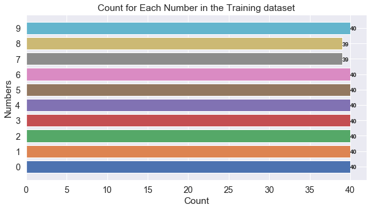

```python
numbers = np.arange(10) # y-axis : Numbers 0 to 9
count = sum(y_train).astype('int') # x-axis : Number of records for each number in the dataset
colors = sns.color_palette(None, 10) # 10 random colors
fig, ax = plt.subplots(figsize=(10,5))
ax.barh(numbers, count, color=colors)
plt.title('Count for Each Number in the Training dataset')
plt.xlabel('Count')
plt.ylabel('Numbers')
plt.yticks(numbers) # Display all the x coordinates

# Display Count at end of each bar
for i, v in enumerate(count):
    ax.text(v, i-0.15, str(v), fontweight='bold')
plt.show()
```

```
Testing model with number of hidden layers = 100, learning rate = 0.1, no. of epochs = 50

Train accuracy: 0.9316546771166135
Train loss: 0.5523828413846682
Test accuracy: 0.8493723848873601
Test loss: 0.7348254966935354
```

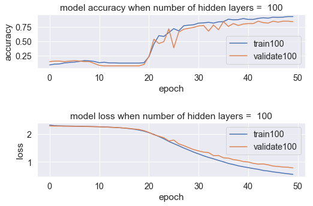

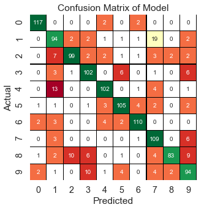

```
Classification Report:
              precision    recall  f1-score   support

           0       0.95      0.97      0.96       121
           1       0.74      0.77      0.76       122
           2       0.88      0.83      0.86       119
           3       0.83      0.86      0.84       119
           4       0.89      0.84      0.86       121
           5       0.88      0.88      0.88       119
           6       0.92      0.91      0.91       121
           7       0.75      0.92      0.82       119
           8       0.95      0.72      0.82       116
           9       0.77      0.80      0.78       118

   micro avg       0.85      0.85      0.85      1195
   macro avg       0.86      0.85      0.85      1195
weighted avg       0.86      0.85      0.85      1195

Accuracy Score of the model: 0.8493723849372385
```

```python
# Neural Network model developed with 25% of the data for training
run_neural_network(X_train, y_train, X_test, y_test, hidden_layers_count = 100, learning_rate = 0.1, epoch_count = 50)
```

#### Epoch vs Accuracy plot for train and test data of the 25% as training data model is shown in the figure below:

```
Testing model with number of hidden layers = 100, learning rate = 0.1, no. of epochs = 50
```

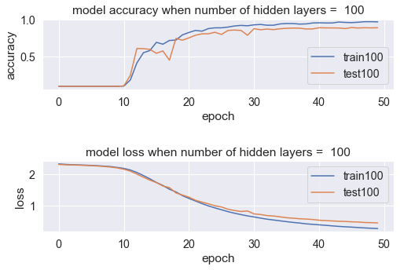

```python
# Epoch vs Accuracy on training and testing data when 25% of the data was used for training the model
epoch_vs_accuracy(X_train, y_train, X_test, y_test, hidden_layers_count = 100, learning_rate = 0.1, epoch_count = 50)
```

```python
# Finding the Number of Epochs needed for Neural Network model developed with 25% of the data for training the model
hidden_vs_epoch(X_train, y_train, X_test, y_test, hidden_layers_count = 100, learning_rate = 0.1, epoch_count = 200)
```

```
Testing model with number of hidden layers = 100, no. of epochs = 200

Number of epochs: 97
```

# Training the network with Half of the data for training the model

```python
X_train, X_test, y_train, y_test = train_test_split(X, y,
                                                    stratify=y,
                                                    test_size=0.5) # training size = 0.5
print("Number of records in our training data : ",len(y_train))
```

```
Number of records in our training data :  796
```

```
Testing model with number of hidden layers = 100, learning rate = 0.1, no. of epochs = 50

Train accuracy: 0.9838420108790029
Train loss: 0.19966041768902723
Test accuracy: 0.9071518186493829
Test loss: 0.37887569039200003
```

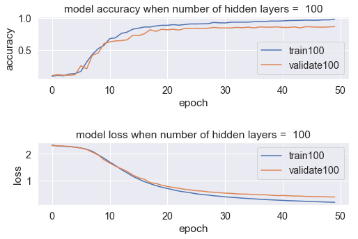

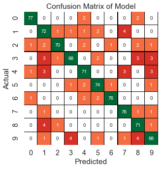

```
Classification Report:
              precision    recall  f1-score   support

           0       0.96      0.95      0.96        81
           1       0.84      0.89      0.86        81
           2       0.96      0.89      0.92        79
           3       0.92      0.85      0.88        80
           4       0.89      0.88      0.88        81
           5       0.91      0.94      0.92        79
           6       0.97      0.94      0.96        81
           7       0.90      0.96      0.93        79
           8       0.86      0.92      0.89        77
           9       0.87      0.86      0.87        79

   micro avg       0.91      0.91      0.91       797
   macro avg       0.91      0.91      0.91       797
weighted avg       0.91      0.91      0.91       797

Accuracy Score of the model: 0.9071518193224593
```

```python
# Neural Network model developed with 50% of the data for training
run_neural_network(X_train, y_train, X_test, y_test, hidden_layers_count = 100, learning_rate = 0.1, epoch_count = 50)
```

#### Epoch vs Accuracy plot for train and test data of the 50% as training data model is shown in the figure below:

```
Testing model with number of hidden layers = 100, learning rate = 0.1, no. of epochs = 50
```

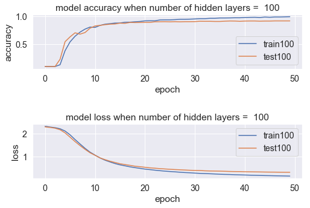

```python
# Epoch vs Accuracy on training and testing data when 50% of the data was used for training the model
epoch_vs_accuracy(X_train, y_train, X_test, y_test, hidden_layers_count = 100, learning_rate = 0.1, epoch_count = 50)
```

```python
# Finding the Number of Epochs needed for Neural Network model developed with Half of the data for training the model
hidden_vs_epoch(X_train, y_train, X_test, y_test, hidden_layers_count = 100, learning_rate = 0.1, epoch_count = 200)
```

```
Testing model with number of hidden layers = 100, no. of epochs = 200

Number of epochs: 66
```

# Effect of size of training data on the final accuracy on the test data:

| Training Data Percentage | Training data Size | Accuracy |
| --- | --- | --- |
| 25% | 398 | 0.8493723849372385 |
| 50% | 796 | 0.9071518193224593 |

More data for training, better the model and better the accuracy.

# Effect of size of training data on the number of epochs needed for training to converge:

| Training Data Percentage | Training data Size | Number of Epochs |
| --- | --- | --- |
| 25% | 398 | 97 |
| 50% | 796 | 66 |

When we have more data for training, the Number of epochs required for the training data to converge becomes less.

# Is there overfitting of our training data?

The accuracy vs epoch graphs plotted above for the 25% training data model shows that there is noticeable decrease in the accuracy of validation data in comparison to the training data. This shows that the training data is overfitting that model. However, we observe the opposite when comparing the model on train and test data. This makes the model inconsistent.

# Hyper Parameter Tuning to improve the accuracy by finding the best parameters

```python
# The whole data set of 1593 records has almost equal number of records for each number
# Using stratify=y, we can obtain approximately equal number of records in our training sample too.
X_train, X_test, y_train, y_test = train_test_split(X, y,
                                                    stratify=y,
                                                    test_size=0.3)
```

```python
stored_values = {}
# https://stackoverflow.com/questions/7719466/how-to-convert-a-string-to-a-function-in-python
dispatcher = {'SGD' : SGD, 'Adam' : Adam}

def best_neural_network(X_train, y_train, X_test, y_test, hidden_layers_count, hidden_activation, output_activation, optimizer, learning_rate, loss, epoch_count):
    # Initiating the Neural Network model
    model = Sequential()

    # Add the first hidden layer which connects all the input layer nodes and a Bias Unit having value 1
    model.add(Dense(hidden_layers_count,
                    activation=hidden_activation,
                    input_shape = (n_cols,),
                    use_bias=True,
                    bias_initializer='ones'))

    # Output layer with a Bias Unit having value 1
    model.add(Dense(n_categories,
                    activation=output_activation,
                    use_bias=True,
                    bias_initializer='ones'))
    # https://towardsdatascience.com/activation-functions-neural-networks-1cbd9f8d91d6

    # Create SGD optimizer with specified learning rate: my_optimizer
    my_optimizer = dispatcher[optimizer](lr=learning_rate)

    # Compile the model
    model.compile(optimizer=my_optimizer, loss=loss, metrics=['accuracy'])

    # For Stopping optimization when the validation loss hasn't improved for patience epochs. In this case 2 epochs
    early_stopping_monitor = EarlyStopping(patience=2)

    # Fit the model
    history = model.fit(X_train, y_train, validation_split=0.3, epochs=epoch_count, verbose=0, callbacks=[early_stopping_monitor])

    # Evaluating the performance of the model in the test data
    score = model.evaluate(X_test, y_test, verbose=0)

    #Storing the values
    if (len(stored_values))!=0:
        i = (len(stored_values))/3
    else:
        i = 0
    stored_values['hidden_layers_count%d' % (i)] = hidden_layers_count
    stored_values['hidden_activation%d' % (i)] = hidden_activation
    stored_values['output_activation%d' % (i)] = output_activation
    stored_values['optimizer%d' % (i)] = optimizer
    stored_values['learning_rate%d' % (i)] = learning_rate
    stored_values['loss%d' % (i)] = loss
    stored_values['epoch_count%d' % (i)] = epoch_count
    stored_values['train_accuracy%d' % (i)] = max(history.history['acc'])
    stored_values['train_loss%d' % (i)] = min(history.history['loss'])
    stored_values['test_accuracy%d' % (i)] = score[1]
    stored_values['test_loss%d' % (i)] = score[0]
```

```python
%%time
hidden_layers_counts = [20,50,100]
hidden_activations = [None, 'relu', 'tanh', 'sigmoid']
output_activations = ['softmax', 'sigmoid']
optimizers = ['SGD', 'Adam']
learning_rates = [0.01, 1, 10]
losses = ['binary_crossentropy', 'categorical_hinge', 'categorical_crossentropy']
# Since we will stop fitting if the accuracy doesn't improve after 2 epochs it is okay to give a high epoch value.
# Varying the epochs isn't required since it will be automatically stopped by our EarlyStopping function with patience=2.
epoch_counts = [100]

i=0
for hidden_layers_count in hidden_layers_counts:
    for hidden_activation in hidden_activations:
        for output_activation in output_activations:
            for optimizer in optimizers:
                for learning_rate in learning_rates:
                    for loss in losses:
                        for epoch_count in epoch_counts:
                            best_neural_network(X_train, y_train, X_test, y_test,
                                                hidden_layers_count = hidden_layers_count,
                                                hidden_activation = hidden_activation,
                                                output_activation = output_activation,
                                                optimizer = optimizer,
                                                learning_rate = learning_rate,
                                                loss = loss,
                                                epoch_count = epoch_count)
                            i=i+1
                            print('Number of combinations completed = '
                                  +str(i)
                                  +' out of '
                                  +str(len(hidden_layers_counts)*len(hidden_activations)*len(output_activations)*len(optimizers)
                                       *len(learning_rates)*len(losses)*len(epoch_counts))
                                  +' combinations')
```

[output not shown]

[output cut: 378 more lines]

[output not shown]

```python
# Storing the results as an array instead of a dictionary
results_table = np.asarray(list(stored_values.values())) #results_table.shape gives (4752, )
# Dividing the total array into rows with 11 columns each
results_table = results_table.reshape(int(len(results_table)/11),11) # results_table.shape gives (432, 11)
# Converting array to Pandas Dataframe
results_table = pd.DataFrame(results_table,columns=['hidden_layers_count', 'hidden_activation', 'output_activation', 'optimizer', 'learning_rate', 'loss', 'epoch_count', 'train_accuracy', 'train_loss', 'test_accuracy', 'test_loss'])
# Finding the best parameters which results in highest accuracy
results_table.sort_values(by='test_accuracy', ascending=False).head(1)
```

|  | hidden_layers_count | hidden_activation | output_activation | optimizer | learning_rate | loss | epoch_count | train_accuracy | train_loss | test_accuracy | test_loss |
| --- | --- | --- | --- | --- | --- | --- | --- | --- | --- | --- | --- |
| 261 | 50 | sigmoid | softmax | Adam | 0.01 | binary_crossentropy | 100 | 1 | 0.002982 | 0.985146 | 0.0480574 |

```python
# Best Accuracy
results_table.sort_values(by='test_accuracy', ascending=False).head(1).loc[:, ['test_accuracy']]
```

|  | test_accuracy |
| --- | --- |
| 261 | 0.985146 |

```python
# Saving the results to csv file
results_table.to_csv('HyperParameterTuningResults.csv')
```

```python
# Number of columns to have in our imported csv
column_count = len(['hidden_layers_count', 'hidden_activation', 'output_activation', 'optimizer', 'learning_rate', 'loss', 'epoch_count', 'train_accuracy', 'train_loss', 'test_accuracy', 'test_loss'])
column_count
```

```
11
```

```python
# Opening the csv file to check the accuracies of different parameters tried
results_table = pd.read_csv('HyperParameterTuningResults.csv', usecols=range(1,column_count+1))
```

```python
results_table.sort_values(by='test_accuracy', ascending=False).head(10)
```

|  | hidden_layers_count | hidden_activation | output_activation | optimizer | learning_rate | loss | epoch_count | train_accuracy | train_loss | test_accuracy | test_loss |
| --- | --- | --- | --- | --- | --- | --- | --- | --- | --- | --- | --- |
| 261 | 50 | sigmoid | softmax | Adam | 0.01 | binary_crossentropy | 100 | 1.000000 | 0.002982 | 0.985146 | 0.048057 |
| 219 | 50 | tanh | softmax | SGD | 1.00 | binary_crossentropy | 100 | 0.998974 | 0.012974 | 0.984519 | 0.052489 |
| 333 | 100 | relu | softmax | Adam | 0.01 | binary_crossentropy | 100 | 1.000000 | 0.000487 | 0.983891 | 0.058470 |
| 369 | 100 | tanh | softmax | Adam | 0.01 | binary_crossentropy | 100 | 1.000000 | 0.000725 | 0.983891 | 0.053054 |
| 327 | 100 | relu | softmax | SGD | 1.00 | binary_crossentropy | 100 | 1.000000 | 0.005138 | 0.983682 | 0.051425 |
| 153 | 50 | NaN | softmax | Adam | 0.01 | binary_crossentropy | 100 | 1.000000 | 0.001887 | 0.983264 | 0.061199 |
| 255 | 50 | sigmoid | softmax | SGD | 1.00 | binary_crossentropy | 100 | 0.998718 | 0.016089 | 0.983054 | 0.054023 |
| 189 | 50 | relu | softmax | Adam | 0.01 | binary_crossentropy | 100 | 1.000000 | 0.000717 | 0.983054 | 0.055007 |
| 147 | 50 | NaN | softmax | SGD | 1.00 | binary_crossentropy | 100 | 0.998590 | 0.012934 | 0.982845 | 0.052179 |
| 111 | 20 | sigmoid | softmax | SGD | 1.00 | binary_crossentropy | 100 | 0.997949 | 0.019882 | 0.982636 | 0.057380 |

loss='binary_crossentropy' seems to be the default value in the top 10 models based on best test accuracy.

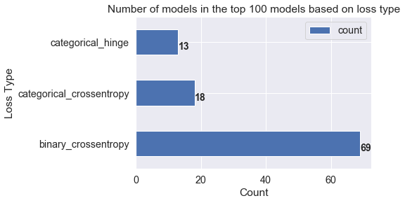

```python
# Top 50 Models best on best test accuracy.
top_100 = results_table.sort_values(by='test_accuracy', ascending=False).head(100)
top_100 = top_100.groupby(["loss"], as_index=False).size().to_frame(name='count').reset_index()

# Plot Graph
top_100.plot(kind='barh', x='loss')
plt.title('Number of models in the top 100 models based on loss type')
plt.xlabel('Count')
plt.ylabel('Loss Type')
count = top_100['count'].values.astype('int')
for i, v in enumerate(count):
    plt.text(v, i-0.15, str(v), fontweight='bold', fontsize=14)
plt.show()
```

```python
# Finding the accuracy of models other than models with 'binary_crossentropy' loss type
results_table[(results_table.loss != 'binary_crossentropy')].sort_values(by='test_accuracy', ascending=False).head(10)
```

|  | hidden_layers_count | hidden_activation | output_activation | optimizer | learning_rate | loss | epoch_count | train_accuracy | train_loss | test_accuracy | test_loss |
| --- | --- | --- | --- | --- | --- | --- | --- | --- | --- | --- | --- |
| 424 | 100 | sigmoid | sigmoid | Adam | 0.01 | categorical_hinge | 100 | 0.993590 | 0.024898 | 0.930962 | 0.213452 |
| 227 | 50 | tanh | softmax | Adam | 0.01 | categorical_crossentropy | 100 | 1.000000 | 0.005212 | 0.926778 | 0.284466 |
| 263 | 50 | sigmoid | softmax | Adam | 0.01 | categorical_crossentropy | 100 | 1.000000 | 0.025017 | 0.926778 | 0.278989 |
| 371 | 100 | tanh | softmax | Adam | 0.01 | categorical_crossentropy | 100 | 1.000000 | 0.008089 | 0.922594 | 0.276507 |
| 370 | 100 | tanh | softmax | Adam | 0.01 | categorical_hinge | 100 | 0.996154 | 0.008436 | 0.922594 | 0.173181 |
| 346 | 100 | relu | sigmoid | SGD | 1.00 | categorical_hinge | 100 | 0.983333 | 0.051509 | 0.922594 | 0.244307 |
| 389 | 100 | tanh | sigmoid | Adam | 0.01 | categorical_crossentropy | 100 | 1.000000 | 0.003722 | 0.920502 | 0.301877 |
| 256 | 50 | sigmoid | softmax | SGD | 1.00 | categorical_hinge | 100 | 0.998718 | 0.012514 | 0.918410 | 0.199918 |
| 383 | 100 | tanh | sigmoid | SGD | 1.00 | categorical_crossentropy | 100 | 1.000000 | 0.009511 | 0.918410 | 0.330184 |
| 382 | 100 | tanh | sigmoid | SGD | 1.00 | categorical_hinge | 100 | 0.991026 | 0.028252 | 0.918410 | 0.232738 |

We can try to further improve the accuracy by changing the bias unit and number of hidden layers

```python
hidden_layers_count = 100
hidden_activation = 'sigmoid'
output_activation = 'softmax'
optimizer = 'Adam'
dispatcher = {'Adam' : Adam}
learning_rate = 0.01
loss = 'binary_crossentropy'

# Initiating the Neural Network model
model = Sequential()

# Add the first hidden layer which connects all the input layer nodes
model.add(Dense(hidden_layers_count,
                activation=hidden_activation,
                input_shape = (n_cols,)))

# Add the second hidden layer which connects all the first hidden layer nodes
model.add(Dense(hidden_layers_count,
                activation=hidden_activation))

# Output layer with a Bias Unit having value 1
model.add(Dense(n_categories,
                activation=output_activation,
                use_bias=True,
                bias_initializer='ones'))

# Create SGD optimizer with specified learning rate: my_optimizer
my_optimizer = dispatcher[optimizer](lr=learning_rate)

# Compile the model
model.compile(optimizer=my_optimizer, loss=loss, metrics=['accuracy'])

# For Stopping optimization when the validation loss hasn't improved for patience epochs. In this case 2 epochs
early_stopping_monitor = EarlyStopping(patience=2)

# Fit the model
history = model.fit(X_train, y_train, validation_split=0.3, epochs=epoch_count, verbose=0, callbacks=[early_stopping_monitor])

# Evaluating the performance of the model in the test data
score = model.evaluate(X_test, y_test, verbose=0)

print('train_accuracy',max(history.history['acc']))
print('train_loss',min(history.history['loss']))
print('test_accuracy',score[1])
print('test_loss',score[0])
```

```
train_accuracy 1.0
train_loss 0.0016609722240947377
test_accuracy 0.9826359918426769
test_loss 0.053495068508336734
```

Removing the bias units, adding a new hidden layers etc. doesn't increase the accuracy but decrease it. Hence we have already achieved the best model.

```
train_binary_accuracy 1.0
train_categorical_accuracy 1.0
train_loss 0.0019131520595879127
test_binary_accuracy 0.9849372518611254
test_categorical_accuracy 0.914225941671986
test_loss 0.04880732965020455
```

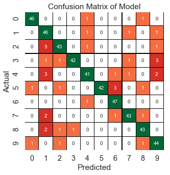

```
Classification Report:
              precision    recall  f1-score   support

           0       0.96      0.96      0.96        48
           1       0.81      0.94      0.87        49
           2       0.91      0.90      0.91        48
           3       0.98      0.88      0.92        48
           4       0.91      0.85      0.88        48
           5       1.00      0.88      0.93        48
           6       0.90      0.98      0.94        48
           7       0.93      0.91      0.92        47
           8       0.91      0.91      0.91        47
           9       0.86      0.94      0.90        47

   micro avg       0.91      0.91      0.91       478
   macro avg       0.92      0.91      0.91       478
weighted avg       0.92      0.91      0.91       478

Accuracy Score of the model: 0.9142259414225942
```

```python
hidden_layers_count = 100
hidden_activation = 'sigmoid'
output_activation = 'softmax'
optimizer = 'Adam'
dispatcher = {'Adam' : Adam}
learning_rate = 0.01
loss = 'binary_crossentropy'

# Initiating the Neural Network model
model = Sequential()

# Add the first hidden layer which connects all the input layer nodes and a Bias Unit having value 1
model.add(Dense(hidden_layers_count,
                activation=hidden_activation,
                input_shape = (n_cols,),
                use_bias=True,
                bias_initializer='ones'))

# Output layer with a Bias Unit having value 1
model.add(Dense(n_categories,
                activation=output_activation,
                use_bias=True,
                bias_initializer='ones'))

# Create SGD optimizer with specified learning rate: my_optimizer
my_optimizer = dispatcher[optimizer](lr=learning_rate)

# Compile the model
model.compile(optimizer=my_optimizer, loss=loss, metrics=['binary_accuracy', 'categorical_accuracy'])
# changing metrics from 'accuracy' to ['binary_accuracy', 'categorical_accuracy']
# https://stackoverflow.com/questions/45799474/keras-model-evaluate-vs-model-predict-accuracy-difference-in-multi-class-nlp-ta

# For Stopping optimization when the validation loss hasn't improved for patience epochs. In this case 2 epochs
early_stopping_monitor = EarlyStopping(patience=2)

# Fit the model
history = model.fit(X_train, y_train, validation_split=0.3, epochs=epoch_count, verbose=0, callbacks=[early_stopping_monitor])

# Evaluating the performance of the model in the test data
score = model.evaluate(X_test, y_test, verbose=0)

print('train_binary_accuracy',max(history.history['binary_accuracy']))
print('train_categorical_accuracy',max(history.history['categorical_accuracy']))
print('train_loss',min(history.history['loss']))
print('test_binary_accuracy',score[1])
print('test_categorical_accuracy',score[2])
print('test_loss',score[0])

# Predicted values for each number and for each record
y_pred = model.predict(X_test)

#Getting the value of actual and predicted number for confusion matrix
actual = np.argmax(y_test, axis = 1)  # Since each prediction is a one hot encoded array
prediction = np.argmax(y_pred, axis = 1)  # Since each prediction is a one hot encoded array

# Finding the Confusion Matrix
cm = confusion_matrix(actual, prediction)

# Visualizing Confusion Matrix
plot_confusion_matrix(cm)

# Print the Classification Report
print('Classification Report: \n'+classification_report(actual, prediction))

#Print Accuracy Score
test_accuracy = accuracy_score(actual, prediction)
print('Accuracy Score of the model: ' + str(test_accuracy))
```

The prediction accuracy seems to be different from the test_binary_accuracy. This is expected since the accuracy shown above is the test_categorical_accuracy.

https://stackoverflow.com/questions/45799474/keras-model-evaluate-vs-model-predict-accuracy-difference-in-multi-class-nlp-ta https://stackoverflow.com/questions/42081257/keras-binary-crossentropy-vs-categorical-crossentropy-performance https://stackoverflow.com/questions/41327601/why-is-binary-crossentropy-more-accurate-than-categorical-crossentropy-for-multi

# Using Hyperas to try to improve the accuracy of the model:

```python
def data():
    data = pd.read_csv("http://archive.ics.uci.edu/ml/machine-learning-databases/semeion/semeion.data",
                    delimiter = r"\s+",
                    header=None)
    data = np.asarray(data)
    data = data.astype(np.float)
    X = data[:,:-10]
    y = data[:,-10:]
    x_train, x_test, y_train, y_test = train_test_split(X, y,
                                                    stratify=y,
                                                    test_size=0.3)
    return x_train, y_train, x_test, y_test
```

```python
# Using different choices to try and find the best model
# hidden_layers_count = choice([20,50,100]
# hidden_activation = choice([None, 'elu', 'selu', 'relu', 'tanh', 'sigmoid']
# output_activation = choice(['softmax', 'sigmoid']
# optimizer = choice(['SGD', 'Adam', 'Adagrad', 'Adadelta', 'RMSprop']
# batch_size = choice([64, 128, 200]
# learning_rate = choice([0.01, 0.1, 1, 10]
# loss = choice(['categorical_hinge', 'categorical_crossentropy']

def create_model(x_train, y_train, x_test, y_test):
    dispatcher = {'SGD' : SGD, 'Adam' : Adam, 'Adagrad' : Adagrad, 'Adadelta' : Adadelta, 'RMSprop' : RMSprop}
    model = Sequential()
    model.add(Dense({{choice([20,50,100])}},
                activation={{choice([None, 'elu', 'selu', 'relu', 'tanh', 'sigmoid'])}},
                input_shape = (256,),
                use_bias=True,
                bias_initializer='ones'))
    model.add(Dense(10,
                activation={{choice(['softmax', 'sigmoid'])}},
                use_bias=True,
                bias_initializer='ones'))
    my_optimizer = dispatcher[{{choice(['SGD', 'Adam', 'Adagrad', 'Adadelta', 'RMSprop'])}}](lr={{choice([0.01, 0.1, 1, 10])}})
    model.compile(optimizer=my_optimizer, loss={{choice(['categorical_hinge', 'categorical_crossentropy'])}}, metrics=['accuracy'])
    early_stopping_monitor = EarlyStopping(patience=2)
    history = model.fit(x_train, y_train, batch_size={{choice([64, 128, 200])}}, validation_data=(x_test, y_test), epochs=100, verbose=0, callbacks=[early_stopping_monitor])

    #get the highest validation accuracy of the training epochs
    validation_acc = np.amax(history.history['val_acc'])
    print('Best validation acc of epoch:', validation_acc)
    return {'loss': -validation_acc, 'status': STATUS_OK, 'model': model}
```

```python
# Finding the best model
if __name__ == '__main__':
    best_run, best_model = optim.minimize(model=create_model,
                                          data=data,
                                          algo=tpe.suggest,
                                          max_evals=100,
                                          trials=Trials(),
                                          verbose=2,
                                          notebook_name='Digit Recognizer',
                                          eval_space=True)   # <-- this is the line that puts real values into 'best_run')
    X_train, Y_train, X_test, Y_test = data()
    print("Evaluation of best performing model:")
    print(best_model.evaluate(X_test, Y_test))
    print("Best performing model chosen hyper-parameters:")
    print(best_run)
```

[output not shown]

[output cut: 297 more lines]

```
0.12970711265897153
Best validation acc of epoch:
0.35774058727040947
Best validation acc of epoch:
0.8179916258137595
Best validation acc of epoch:
0.10041841022888487
Best validation acc of epoch:
0.10041841022888487
Best validation acc of epoch:
0.914225941671986
Evalutation of best performing model:
[0.06447258560477939, 0.9790794979079498]
Best performing model chosen hyper-parameters:
{'Dense': 50, 'activation': 'sigmoid', 'activation_1': 'sigmoid', 'activation_2': 'RMSprop', 'batch_size': 128, 'loss': 'categorical_hinge', 'lr': 0.01}
```

```python
# Best Parameters
best_run
```

```
{'Dense': 50,
 'activation': 'sigmoid',
 'activation_1': 'sigmoid',
 'activation_2': 'RMSprop',
 'batch_size': 128,
 'loss': 'categorical_hinge',
 'lr': 0.01}
```

```python
# Testing the best parameters for checking the test data accuracy
hidden_layers_count = 100
hidden_activation = 'sigmoid'
output_activation = 'sigmoid'
optimizer = 'RMSprop'
dispatcher = {'RMSprop' : RMSprop}
batch_size = 128
learning_rate = 0.01
loss = 'categorical_hinge'

X_train, X_test, y_train, y_test = train_test_split(X, y,
                                                    stratify=y,
                                                    test_size=0.3)

# Initiating the Neural Network model
model = Sequential()

# Add the first hidden layer which connects all the input layer nodes
model.add(Dense(hidden_layers_count,
                activation=hidden_activation,
                input_shape = (n_cols,)))

# Add the second hidden layer which connects all the first hidden layer nodes
model.add(Dense(hidden_layers_count,
                activation=hidden_activation))

# Output layer with a Bias Unit having value 1
model.add(Dense(n_categories,
                activation=output_activation,
                use_bias=True,
                bias_initializer='ones'))

# Create SGD optimizer with specified learning rate: my_optimizer
my_optimizer = dispatcher[optimizer](lr=learning_rate)

# Compile the model
model.compile(optimizer=my_optimizer, loss=loss, metrics=['accuracy'])

# For Stopping optimization when the validation loss hasn't improved for patience epochs. In this case 2 epochs
early_stopping_monitor = EarlyStopping(patience=2)

# Fit the model
history = model.fit(X_train, y_train, batch_size=batch_size, validation_split=0.3, epochs=100, verbose=0, callbacks=[early_stopping_monitor])

# Evaluating the performance of the model in the test data
score = model.evaluate(X_test, y_test, verbose=0)

print('train_accuracy',max(history.history['acc']))
print('train_loss',min(history.history['loss']))
print('test_accuracy',score[1])
print('test_loss',score[0])
```

```
train_accuracy 0.996153846459511
train_loss 0.01880574585774388
test_accuracy 0.9372384919781066
test_loss 0.14503113367442805
```

# References:

https://medium.com/analytics-vidhya/neural-networks-for-digits-recognition-e11d9dff00d5  
https://nextjournal.com/gkoehler/digit-recognition-with-keras  
https://www.datacamp.com/courses/deep-learning-in-python